# VI Foundry — Simulacra & Baseline Visualizations

Valence-Ingression framework — empirical proof machinery

Generated: 2026-08-10 06:10 UTC | [GitHub repository](https://github.com/FlowFeel/vi-foundry) | [GitHub Pages](https://flowfeel.github.io/vi-foundry/) | INFERNO — Economic Extrapolations | Calcs & Viz | Revised Domesticate Test | Lab Notes

## Overview

This page renders the VI Foundry proof machinery. Simulacra sections summarize parameter-recovery tests on synthetic data with known ground truth (STDD). The Baseline Oracle section shows every §12 manuscript result with its tolerance band, and the Key Results section reproduces the README results table (T1-T7, formal model, L3).

## 1. Simulacra Overview

[output not shown]

## 2. Simulacra Plots

### autocatalytic_dd

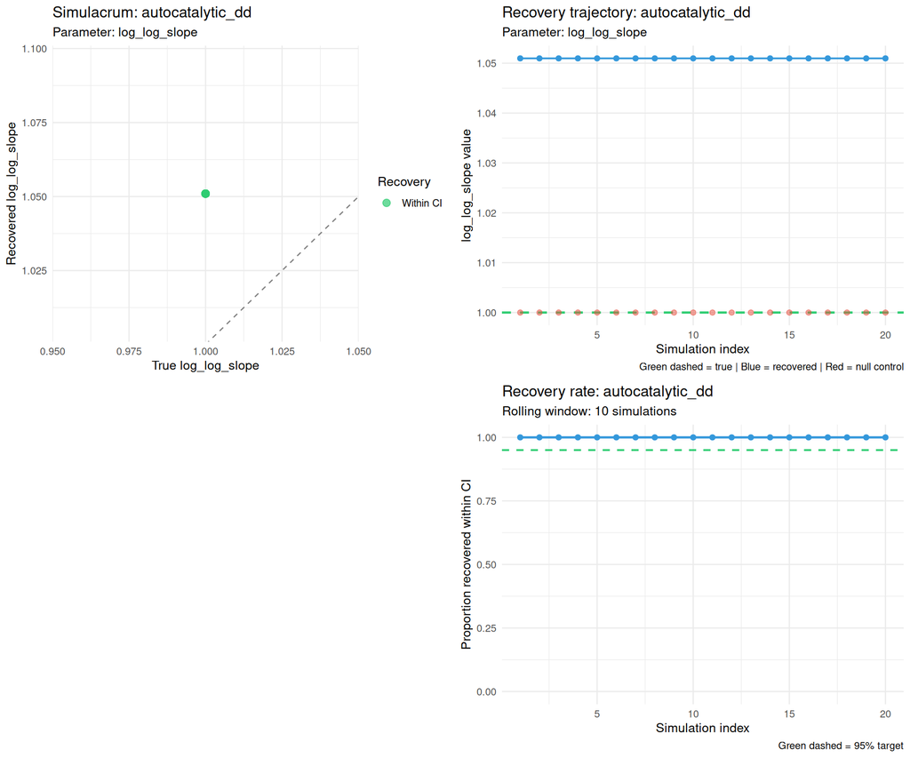

### biphasic_kinetics

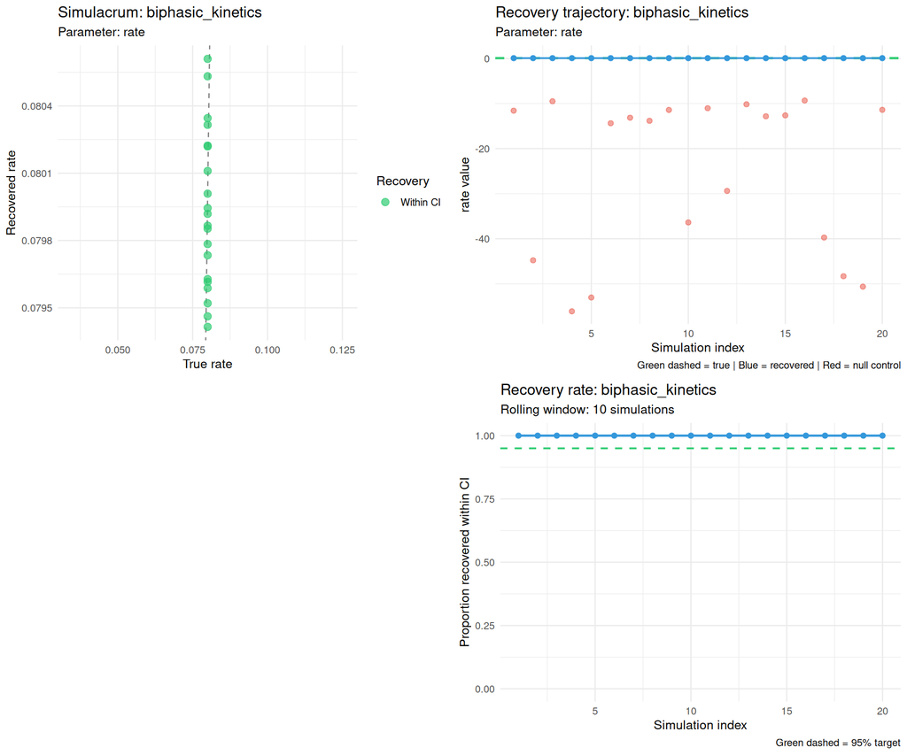

### cross_kingdom_transfer

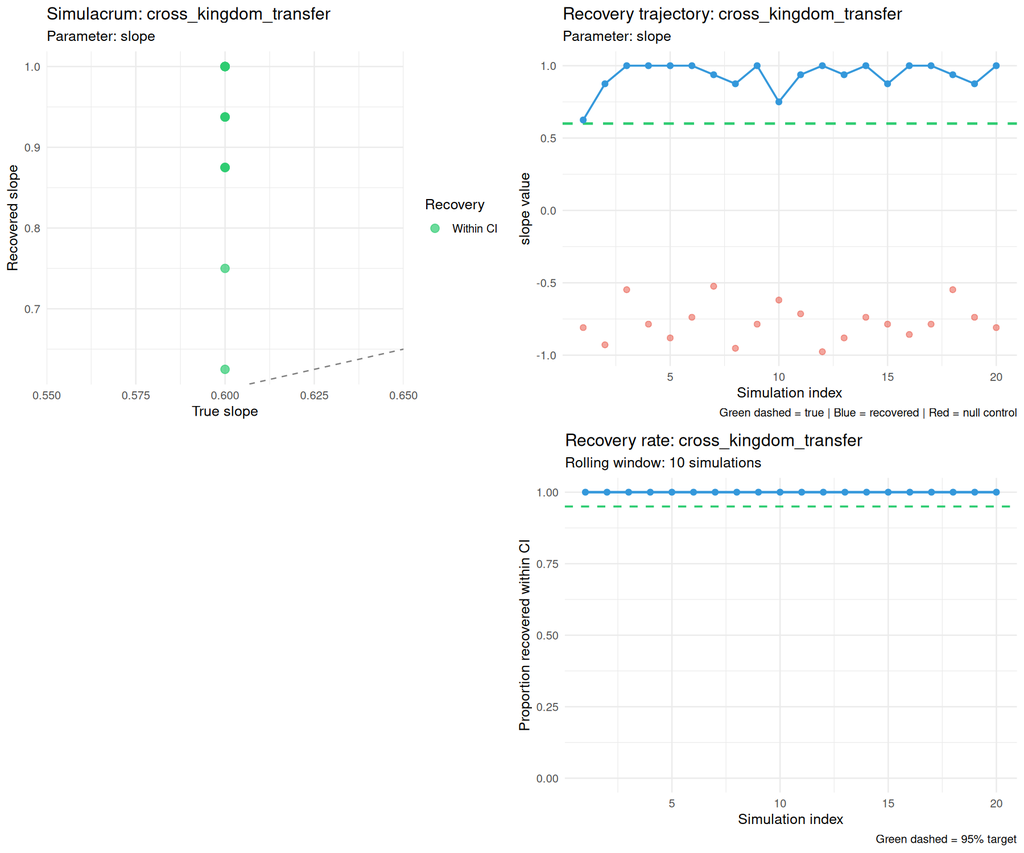

### cusp_bifurcation

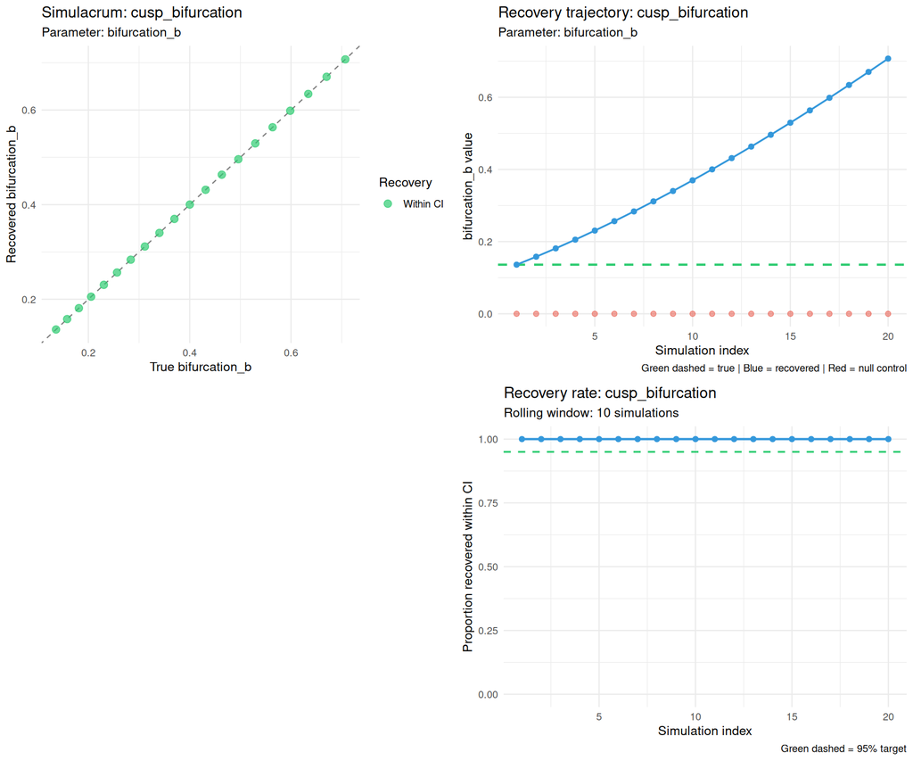

### param_recovery

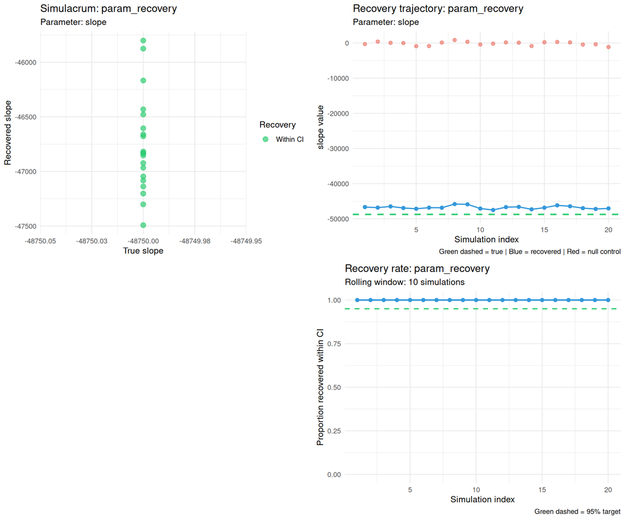

## 3. Baseline Oracle (§12 results)

Every value below is the manuscript-reported result, stored as ground truth in baseline/oracle.yml. The regression CI gate compares pipeline output to these values within numerical tolerance.

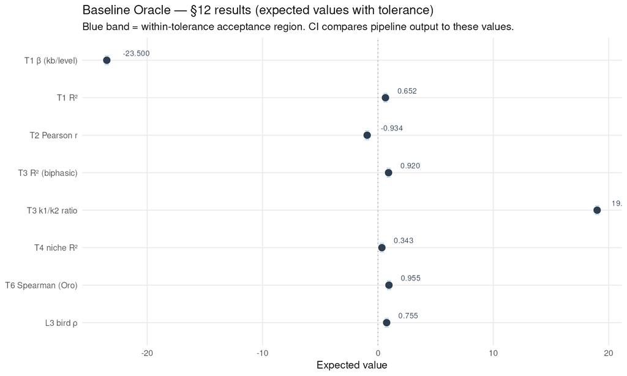

[output not shown]

## 4. Key Results

[output not shown]

## 5. Toy Realms — Speculative Simulation

The toy realms are **speculative simulation, not empirical test**. They make VI's predictions explorable across parameter space and hypothetical substrates, using synthetic data with known parameters. Each realm ends with "the experiment that would fill this realm" — the dataset that would convert it from speculative to empirical. See [the toy realms plan](https://github.com/FlowFeel/vi-foundry/blob/main/docs/review/toy-realms-plan.md) and [the vignette](https://github.com/FlowFeel/vi-foundry/blob/main/vignettes/exploring-toy-realms.Rmd) for the full literate treatment.

### Realm 1 — The threshold gate

**What it explores:** How genome retention collapses as parasitism crosses the protection threshold. Below the threshold, retention is ~1; above, it collapses to ~0. **What it teaches:** The gate is sharp, not gradual — VI predicts a threshold, not a smooth decline.

[figure not shown]

### Realm 2 — Irreversibility

**What it explores:** How hysteresis loop area grows as the cusp system crosses the bifurcation (a < 0). Loop area = 0 for a >= 0 (reversible); rises for a < 0 (irreversible). **What it teaches:** Irreversibility is quantitative (loop area, not just a boolean) and emerges at the bifurcation.

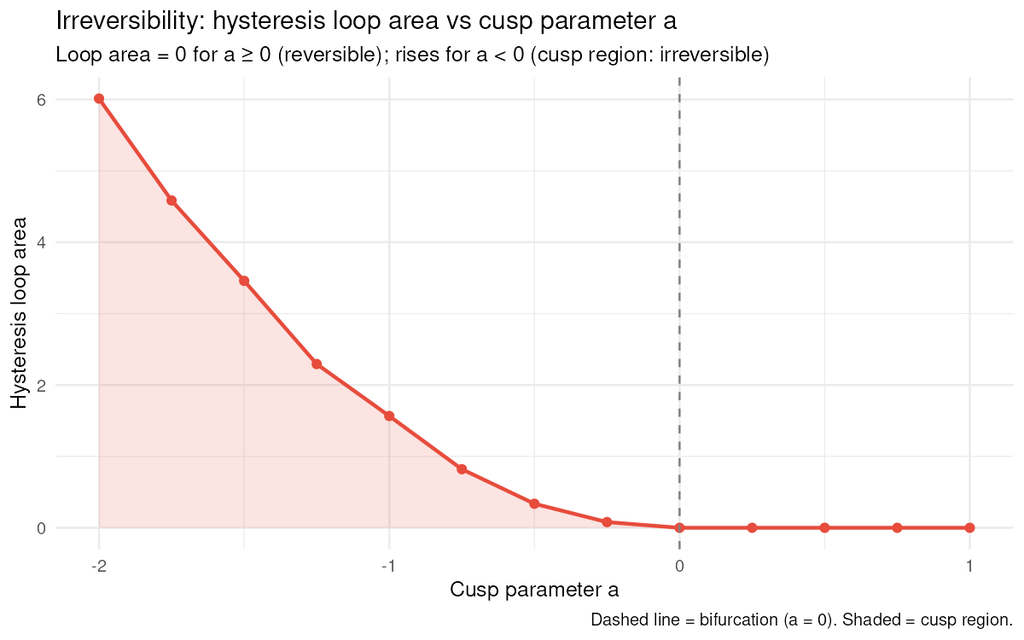

Sweep over a = 1 to -2; shaded region = cusp (irreversible).

### Realm 3 — The Homo inversion

**What it explores:** The diversity-dependence sign flip: positive DD (autocatalytic, the Homo inversion) vs negative DD (logistic, niche-filling). Both trajectories grow, but the per-capita-rate-vs-N slope has opposite signs. **What it teaches:** The Homo inversion is a DD sign flip, not just a growth direction — the discriminator is the slope sign, not whether growth occurs.

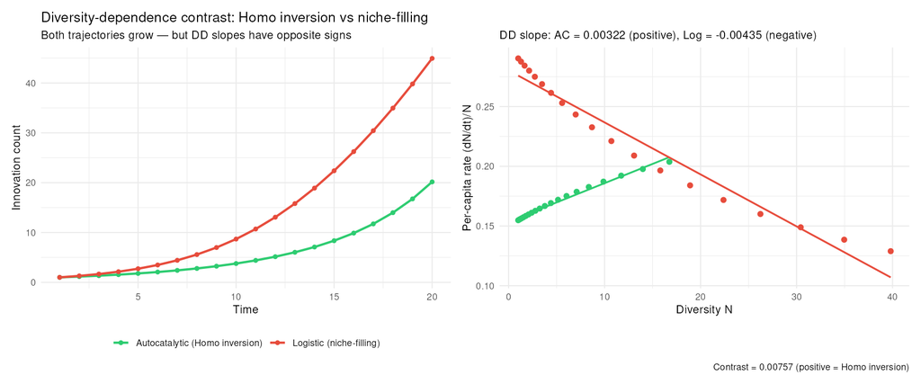

Left: both trajectories grow. Right: AC slope positive (green), logistic negative (red).

### Realm 4 — Cross-kingdom transfer

**What it explores:** When does the full GLM model (dep + para) outperform the sign-only transfer (dep alone)? At low plant noise, the model transfer wins; as noise increases, they converge. **What it teaches:** The gap between the two curves is the information lost to ranking (Issue 7) — the magnitude the sign-only transfer discards.

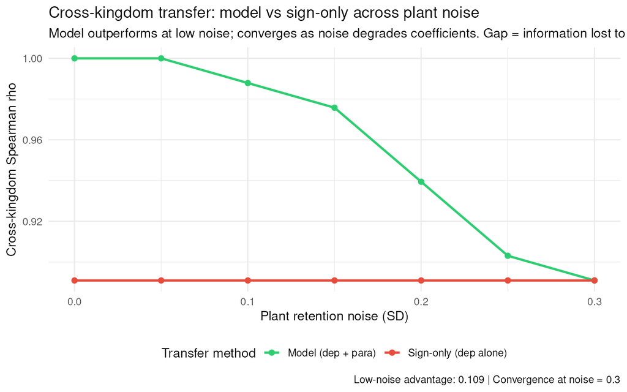

Green = model (dep + para); red = sign-only (dep alone). Gap = info lost to ranking.

**VI Foundry** — production-grade computational artifacts for the Valence-Ingression framework monograph.

Standards: [Phosphene R Standards](https://github.com/FlowFeel/vi-foundry/blob/main/docs/standards/PHOSPHENE_R_STANDARDS.md) | [Repository](https://github.com/FlowFeel/vi-foundry) | [Review docs](https://github.com/FlowFeel/vi-foundry/blob/main/docs/review/README.md) | [Toy realms vignette](https://github.com/FlowFeel/vi-foundry/blob/main/vignettes/exploring-toy-realms.Rmd)

Generated by scripts/render_pages.R at 2026-08-10 06:10 UTC — fully self-contained (no external requests).